# Лабораторная работа №2

Управление пользователями и группами

Цыпин Дмитрий Алексеевич

1032253633@rudn.ru

Российский университет дружбы народов

2026-03-03

# Информация

## Докладчик

- Цыпин Дмитрий Алексеевич
- студент группы НПИбд-02-25
- ст. билет - 1032253633
- Российский университет дружбы народов им. П. Лумумбы
- 1032253633@rudn.ru

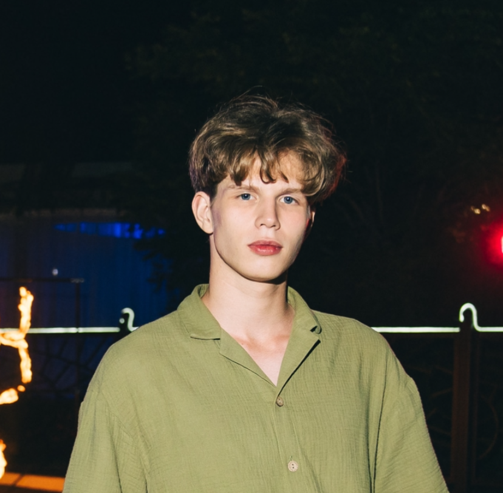

# Вводная часть

## Цель работы

Получить представление о работе с учётными записями пользователей и группами пользователей в операционной системе типа Linux.

## Задание

1. Прочитайте справочное описание man по командам ls, whoami, id, groups, su, sudo, passwd, vi, visudo, useradd, usermod, userdel, groupadd, groupdel.
2. Выполните действия по переключению между учётными записями пользователей, по управлению учётными записями пользователей (раздел 2.4.1).
3. Выполните действия по созданию пользователей и управлению их учётными записями (раздел 2.4.2).
4. Выполните действия по работе с группами пользователей (раздел 2.4.3).

# Выполнение лабораторной работы

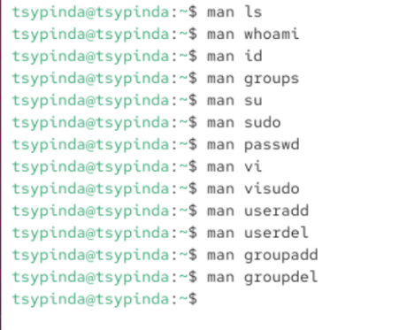

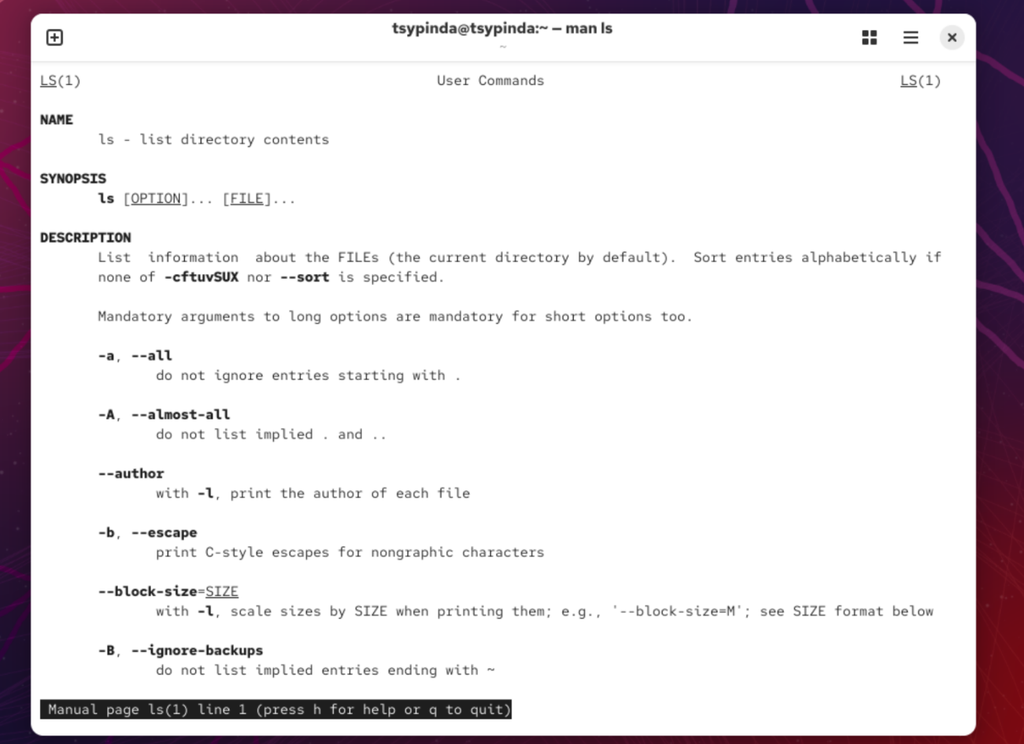

Рисунок 2: man ls

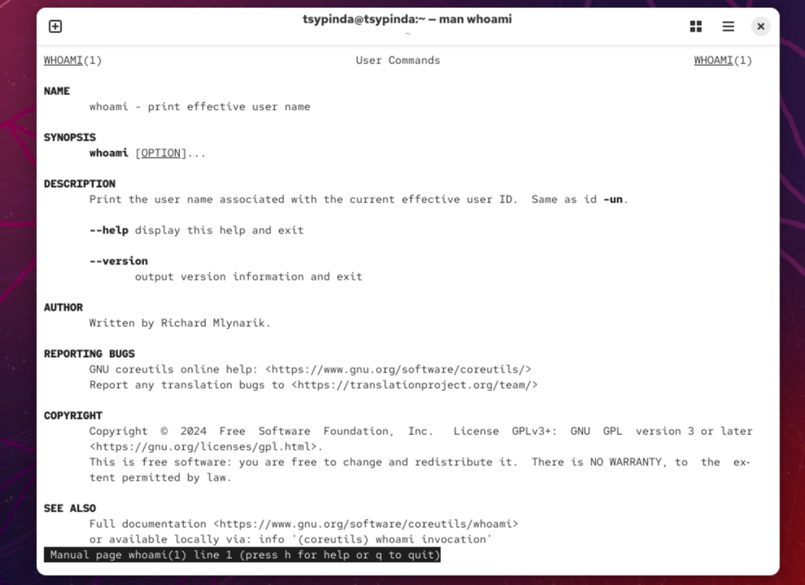

Рисунок 3: man whoami

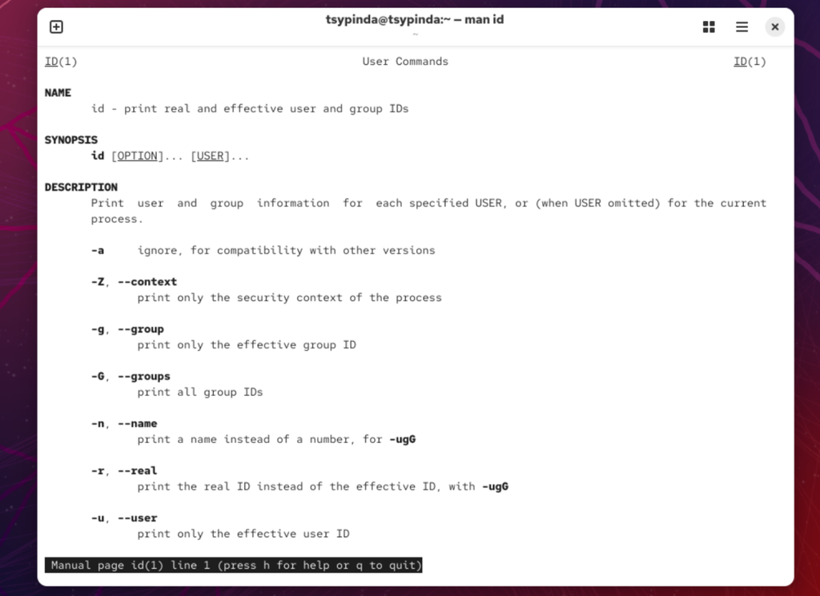

Рисунок 4: man id

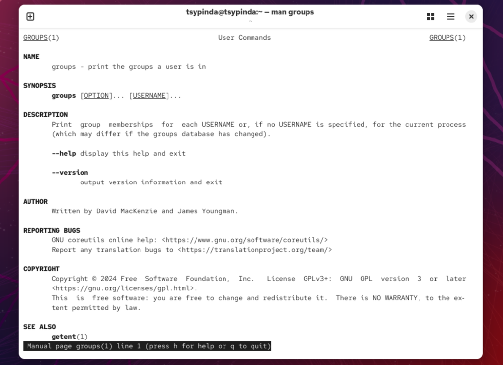

Рисунок 5: man groups

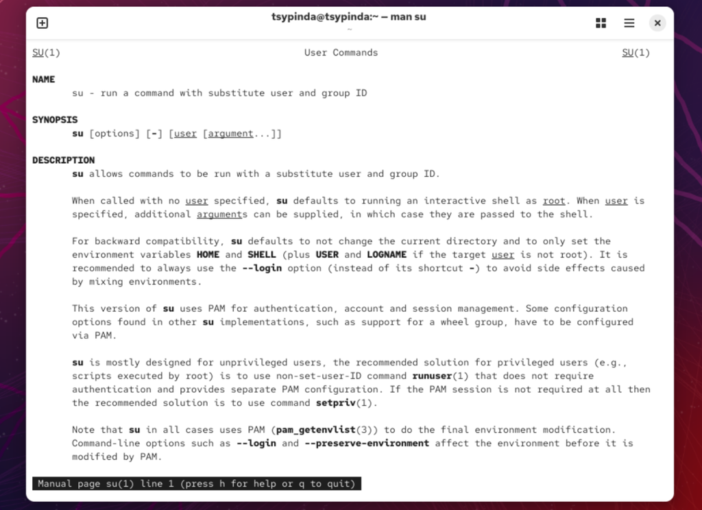

Рисунок 6: man su

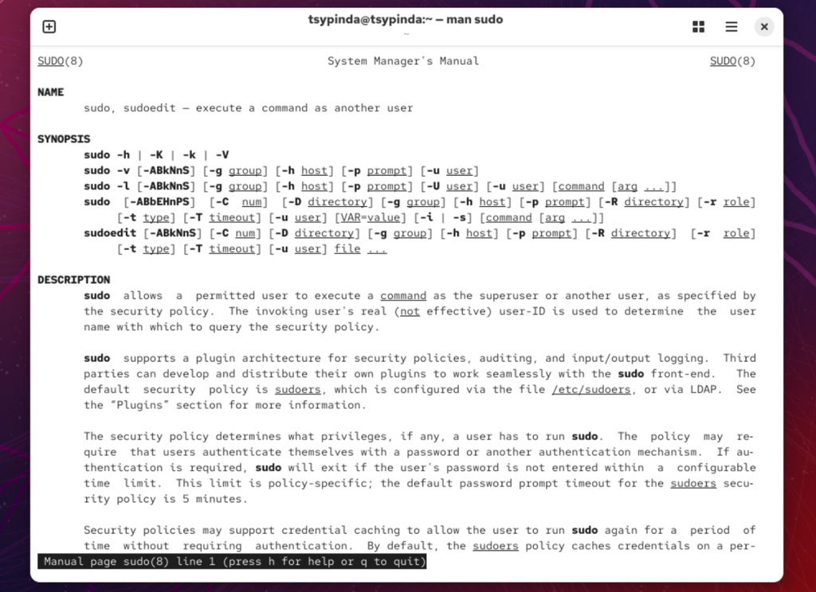

Рисунок 7: man sudo

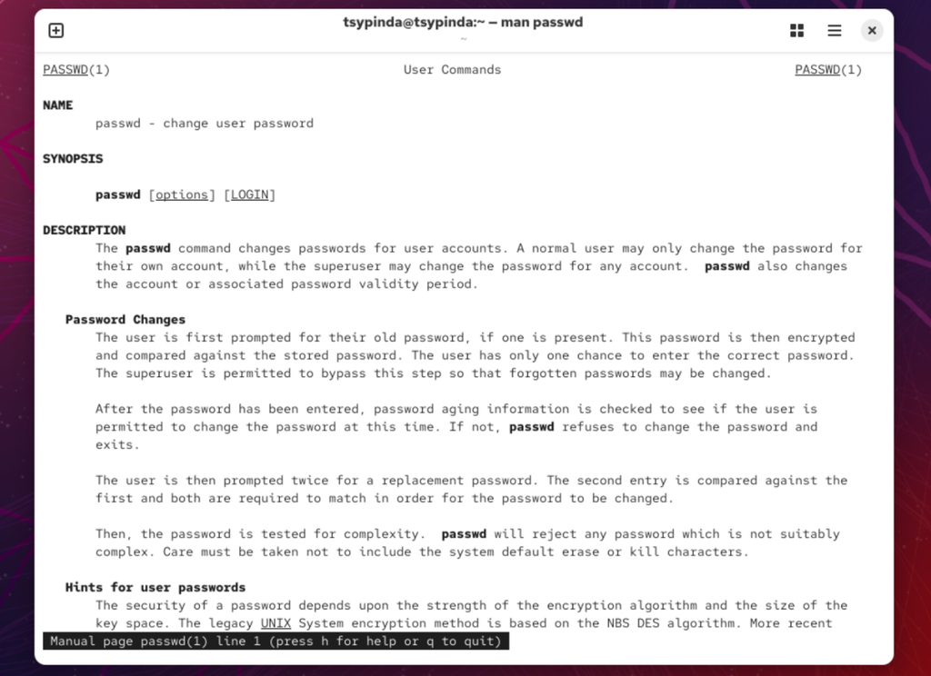

Рисунок 8: man passwd

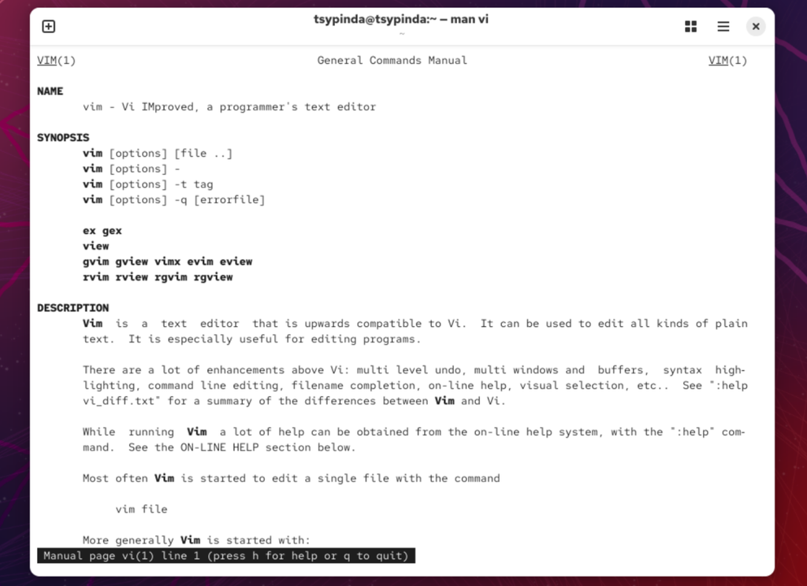

Рисунок 9: man vi

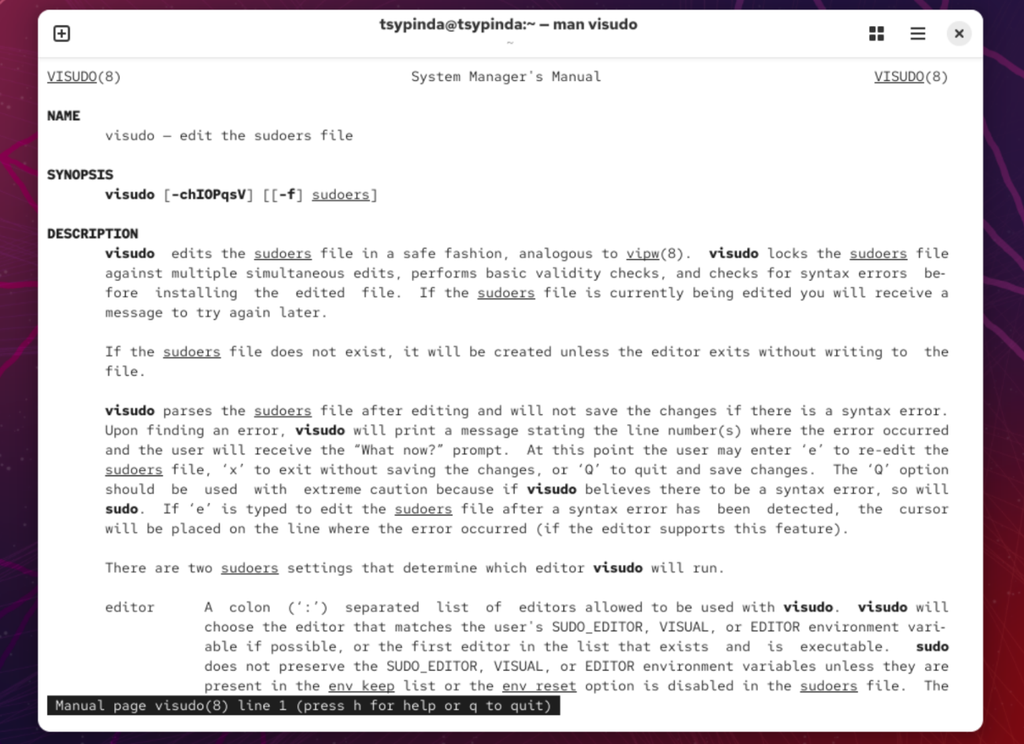

Рисунок 10: man visudo

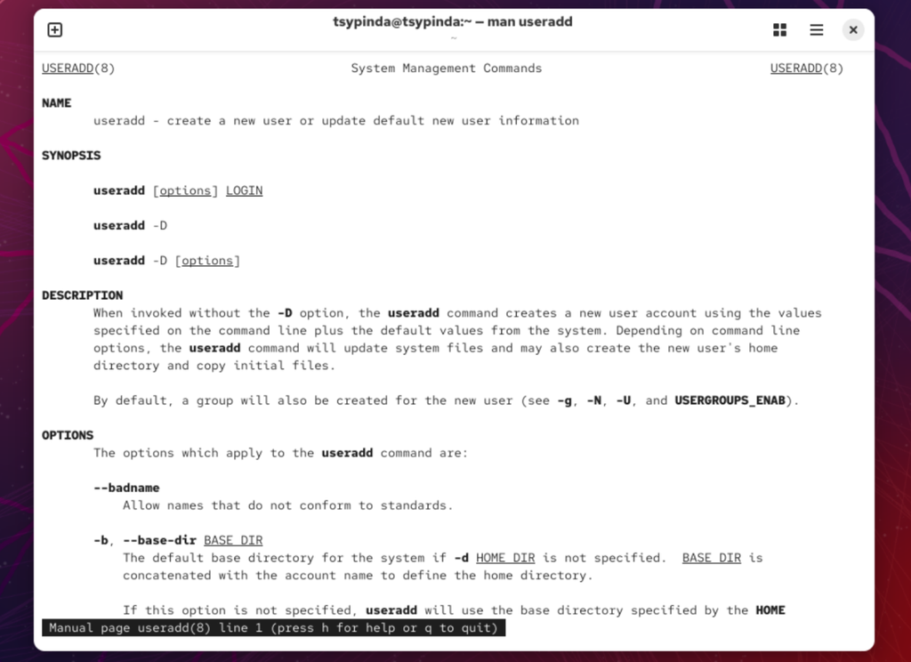

Рисунок 11: man useradd

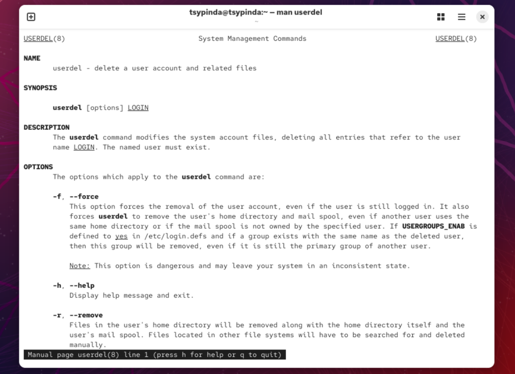

Рисунок 12: man userdel

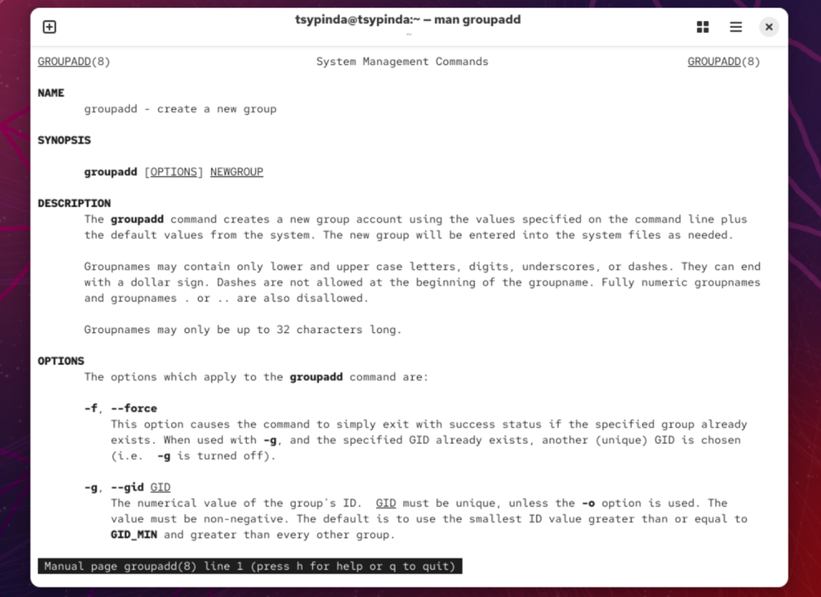

Рисунок 13: man groupadd

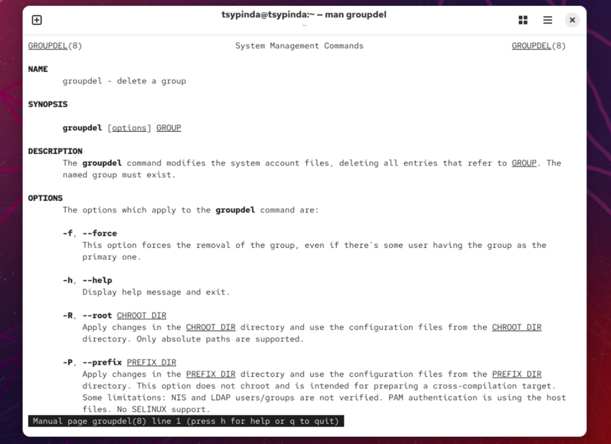

Рисунок 14: man groupdel

Входим в систему как обычный пользователь. В терминале определяем, какую учетную запись используем (рис.15)

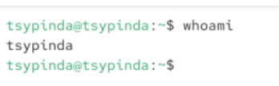

Рисунок 15: whoami

Просматриваем более подробную информацию с помощью id (рис.16)

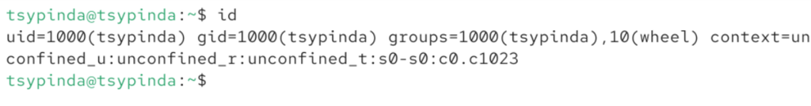

Рисунок 16: id

Переключаем учетную запись в root и повторно смотрим информацию (рис.17). В строчке каждое значение значит следующее: uid=0 - id user’а, в данном случае 0 т.к. root gid=0 - id группы, аналогично 0 т..к root groups - группы root

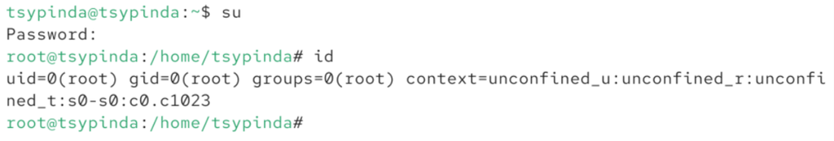

Рисунок 17: su, id

Возвращаемся к изначальной учетной записи (рис.18)

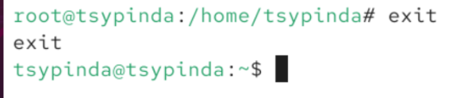

Рисунок 18: exit

Просматриваем в безопасном режиме файл /etc/sudoers (рис.19 - рис.20)

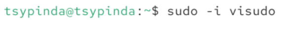

Рисунок 19: sudo -i visudo

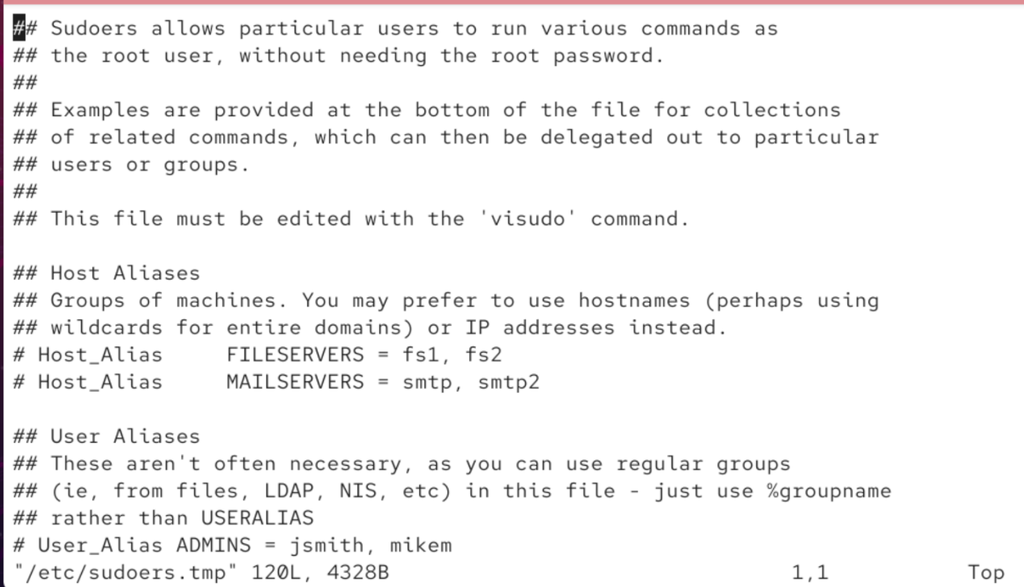

Рисунок 20: Просматриваем сам файл

Находим строчку %wheel ALL=(ALL) ALL (рис.21)

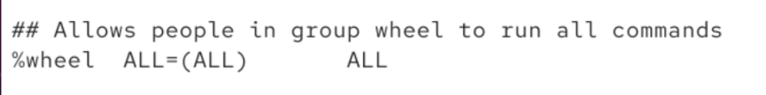

Рисунок 21: %wheel ALL=(ALL) ALL

Создаем пользователя alice с группой wheel. С помощью id убеждаемся в правильности созданного пользователя (рис.22)

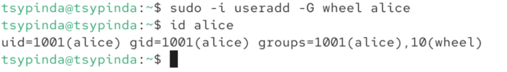

Рисунок 22: sudo -i useradd -G wheel alice

Задаем пароль пользователю alice (рис.23)

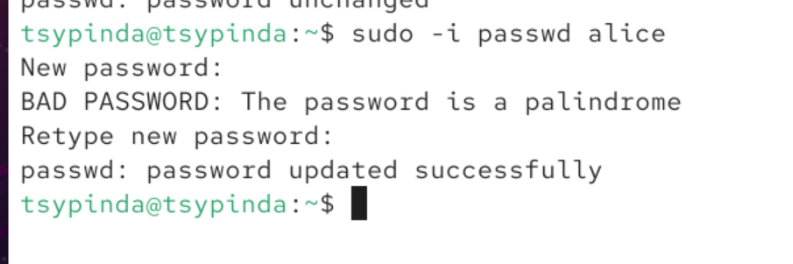

Рисунок 23: sudo -i passwd alice

Переключаемся на alice (рис.24)

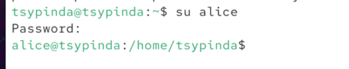

Рисунок 24: su alice

Создаем пользователя bob (рис.25) и задаем ему пароль (рис. 26)

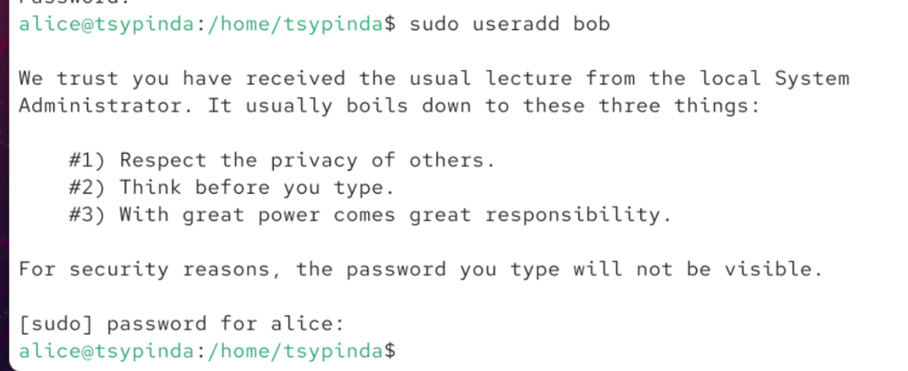

Рисунок 25: sudo useradd bob

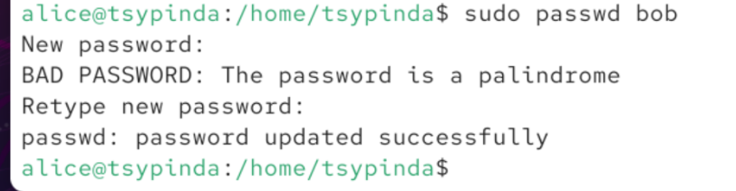

Рисунок 26: sudo passwd bob

Просматриваем, в каких группах находится bob (рис. 27)

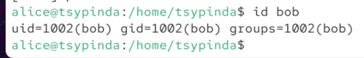

Рисунок 27: id bob

Переключаемся в рут и открываем файл конфигурации /etc/login.defs для редактирования (рис.28)

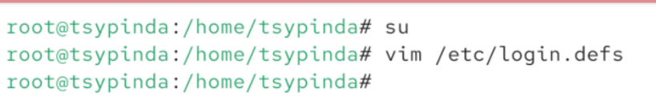

Рисунок 28: vim /etc/login.defs

Проверяем параметр CREATE_HOME (рис.29), меняем USERGROUPS_ENAB на no (рис.30)

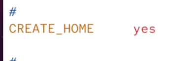

Рисунок 29: CREATE_HOME